# Week 5: Tidying Data

Richard Pantoliano Jr

October 2, 2016

## Problem

Given the data set below, tidy and reshape the data to compare arrival and departure times between the two airlines.

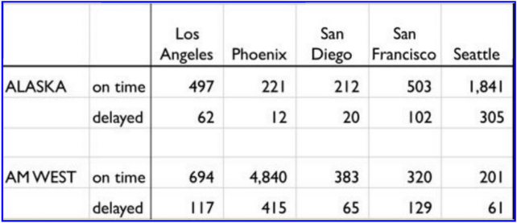

## Creating the CSV File

First, I created a CSV file representing the data pictured above. I assumed each cell of the table shown was a value to be represented in the CSV file, with blank cells representing an empty value. The resulting file is:

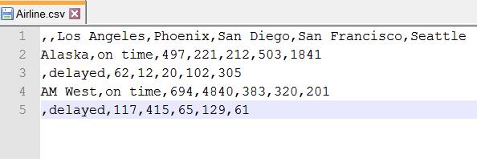

## Reading and initial processing of the CSV Data

Reading the initial file is easy, since R has a function to do so.

```r
airline_df <- read.csv("Airline.csv")
print(airline_df)
```

```
##         X     X.1 Los.Angeles Phoenix San.Diego San.Francisco Seattle
## 1  Alaska on time         497     221       212           503    1841
## 2         delayed          62      12        20           102     305
## 3 AM West on time         694    4840       383           320     201
## 4         delayed         117     415        65           129      61
```

Looking at the dataframe, we notice that the column headers for the airline and the status of the observations are not meaningful, so we shall rename them:

```r
names(airline_df)[1] <- "Airline"
names(airline_df)[2] <- "Status"
print(airline_df)
```

```
##   Airline  Status Los.Angeles Phoenix San.Diego San.Francisco Seattle
## 1  Alaska on time         497     221       212           503    1841
## 2         delayed          62      12        20           102     305
## 3 AM West on time         694    4840       383           320     201
## 4         delayed         117     415        65           129      61
```

We also notice that, for the “delayed” data observations, we do not have the airline associated with those observations listed, so let us change that as well:

```r
airline_df[2,1] <- airline_df[1,1]
airline_df[4,1] <- airline_df[3,1]
print(airline_df)
```

```
##   Airline  Status Los.Angeles Phoenix San.Diego San.Francisco Seattle
## 1  Alaska on time         497     221       212           503    1841
## 2  Alaska delayed          62      12        20           102     305
## 3 AM West on time         694    4840       383           320     201
## 4 AM West delayed         117     415        65           129      61
```

## Separating the data into various useful frames

# Lengthening Data

First, we can lengthen the data table so that each row contains the Airline, Status of Flight, City of flights, and # of flights of that type:

```r
long_df <- airline_df %>%
                  gather("Location", "n",3:7)
print(long_df)
```

```
##    Airline  Status      Location    n
## 1   Alaska on time   Los.Angeles  497
## 2   Alaska delayed   Los.Angeles   62
## 3  AM West on time   Los.Angeles  694
## 4  AM West delayed   Los.Angeles  117
## 5   Alaska on time       Phoenix  221
## 6   Alaska delayed       Phoenix   12
## 7  AM West on time       Phoenix 4840
## 8  AM West delayed       Phoenix  415
## 9   Alaska on time     San.Diego  212
## 10  Alaska delayed     San.Diego   20
## 11 AM West on time     San.Diego  383
## 12 AM West delayed     San.Diego   65
## 13  Alaska on time San.Francisco  503
## 14  Alaska delayed San.Francisco  102
## 15 AM West on time San.Francisco  320
## 16 AM West delayed San.Francisco  129
## 17  Alaska on time       Seattle 1841
## 18  Alaska delayed       Seattle  305
## 19 AM West on time       Seattle  201
## 20 AM West delayed       Seattle   61
```

# By Airline

```r
# Filter observation by airline
alaska_df <- long_df %>% filter(Airline == "Alaska") %>% group_by(Location)
amwest_df <- long_df %>% filter(Airline == "AM West") %>% group_by(Location)
print(alaska_df)
```

```
## Source: local data frame [10 x 4]
## Groups: Location [5]
##
##    Airline  Status      Location     n
##     <fctr>  <fctr>         <chr> <int>
## 1   Alaska on time   Los.Angeles   497
## 2   Alaska delayed   Los.Angeles    62
## 3   Alaska on time       Phoenix   221
## 4   Alaska delayed       Phoenix    12
## 5   Alaska on time     San.Diego   212
## 6   Alaska delayed     San.Diego    20
## 7   Alaska on time San.Francisco   503
## 8   Alaska delayed San.Francisco   102
## 9   Alaska on time       Seattle  1841
## 10  Alaska delayed       Seattle   305
```

```r
print(amwest_df)
```

```
## Source: local data frame [10 x 4]
## Groups: Location [5]
##
##    Airline  Status      Location     n
##     <fctr>  <fctr>         <chr> <int>
## 1  AM West on time   Los.Angeles   694
## 2  AM West delayed   Los.Angeles   117
## 3  AM West on time       Phoenix  4840
## 4  AM West delayed       Phoenix   415
## 5  AM West on time     San.Diego   383
## 6  AM West delayed     San.Diego    65
## 7  AM West on time San.Francisco   320
## 8  AM West delayed San.Francisco   129
## 9  AM West on time       Seattle   201
## 10 AM West delayed       Seattle    61
```

Total number of flights to each location by each airline

```r
alaska_total <- alaska_df %>% group_by(Location) %>% summarise(total = sum(n))
amwest_total <- amwest_df %>% group_by(Location) %>% summarise(total = sum(n))
print(alaska_total)
```

```
## # A tibble: 5 × 2
##        Location total
##           <chr> <int>
## 1   Los.Angeles   559
## 2       Phoenix   233
## 3     San.Diego   232
## 4 San.Francisco   605
## 5       Seattle  2146
```

```r
print(amwest_total)
```

```
## # A tibble: 5 × 2
##        Location total
##           <chr> <int>
## 1   Los.Angeles   811
## 2       Phoenix  5255
## 3     San.Diego   448
## 4 San.Francisco   449
## 5       Seattle   262
```

# By On time Flights

```r
# On-time flights
ontime_df <-
  long_df %>%
  filter(Status == "on time") %>%
  select(-Status) %>%
  group_by(Location)
print(ontime_df)
```

```
## Source: local data frame [10 x 3]
## Groups: Location [5]
##
##    Airline      Location     n
##     <fctr>         <chr> <int>
## 1   Alaska   Los.Angeles   497
## 2  AM West   Los.Angeles   694
## 3   Alaska       Phoenix   221
## 4  AM West       Phoenix  4840
## 5   Alaska     San.Diego   212
## 6  AM West     San.Diego   383
## 7   Alaska San.Francisco   503
## 8  AM West San.Francisco   320
## 9   Alaska       Seattle  1841
## 10 AM West       Seattle   201
```

# By Delayed Flights

```r
delayed_df <-
  long_df %>%
  filter(Status == "delayed") %>%
  select(-Status) %>%
  group_by(Location)
print(delayed_df)
```

```
## Source: local data frame [10 x 3]
## Groups: Location [5]
##
##    Airline      Location     n
##     <fctr>         <chr> <int>
## 1   Alaska   Los.Angeles    62
## 2  AM West   Los.Angeles   117
## 3   Alaska       Phoenix    12
## 4  AM West       Phoenix   415
## 5   Alaska     San.Diego    20
## 6  AM West     San.Diego    65
## 7   Alaska San.Francisco   102
## 8  AM West San.Francisco   129
## 9   Alaska       Seattle   305
## 10 AM West       Seattle    61
```